# Numerical solution of differential equations

Fourth-order Runge-Kutta for simple harmonic motion  
TFY4163 Wave and fluid mechanics - Project  
William Dugan

We define the following: $$ \frac{\partial\omega}{\partial t} = \frac{F_D}{ml}\sin\left(\omega_D t\right) - \frac{g}{l} \theta - q \omega \\ \frac{\partial\theta}{\partial t} = \omega. $$ We then dicretize the time variable and solve the problem iteratively. This is done by iterating the first equation first, then use the result to calculate the next $\theta$. The constants are as defined in the project description, and can be found in cell 3.

We start by importing neccesarry libraries.

```python
import numpy as np
import matplotlib.pyplot as plt
```

Here we define our constants.

```python
l = 1.           # [m]
g = 9.81         # [m/s^2]
theta_0 = 0.2    # [rad]
omega_0 = 0      # [rad]
q = 1.0          # [1/s]
omega_D = 3.13   # [1/s]
drivkraft = 0.2  # [N] F_D / (m l)
u0=(omega_0, theta_0)

t_max = 20.         # [s]
dt = 0.01           # [s]
N = int(t_max//dt)  # [--]
t = np.linspace(0, t_max, int(t_max//dt))
```

### Solver implementation

The `solve()` method takes in a solver function (callable), ie. the Runge-Kutta 4 or Euler-Cromer method defined as `step_RK4()` or `step_EulerCromer()`.

#### A note on readability

The variable *u* is a matrix with dimension $(N, 2)$ where $N$ is the number of time points. The first value of $N_i$ is $\Omega_i$ and the second value is $\theta_i$. In other words, $N_0 = u_0 = (\Omega_0, \theta_0)$. $\Omega$ has to be the first value as this differential equation needs to be iterated first, so we can use the result for solving the one regarding $\theta$.

```python
def step_RK4(f, u, t, n):
    dt = t[n+1] - t[n]
    dt2 = dt/2.0
    k1 = f(u[n], t[n])
    k2 = f(u[n] + dt2*k1, t[n] + dt2)
    k3 = f(u[n] + dt2*k2, t[n] + dt2)
    k4 = f(u[n] + dt*k3, t[n] + dt)
    return u[n] + (dt/6.0)*(k1 + 2*k2 + 2*k3 + k4)

def step_EulerCromer(f, u, t, n):
    dt = t[n+1] - t[n]

    d_omega, d_theta = f(u[n], t[n])
    omega = u[n, 0] + d_omega * dt
    return omega, u[n, 1] + omega * dt

def solve(f, solver, t: np.array, u0: np.array):
    u = np.zeros((len(t), 2))
    u[0] = u0

    for i in range(len(t)-1):
        u[i+1] = solver(f, u, t, i)

    return u
```

## Task 1

The function `dF()` represents the set of differential equaitions and is called by `solve()`.

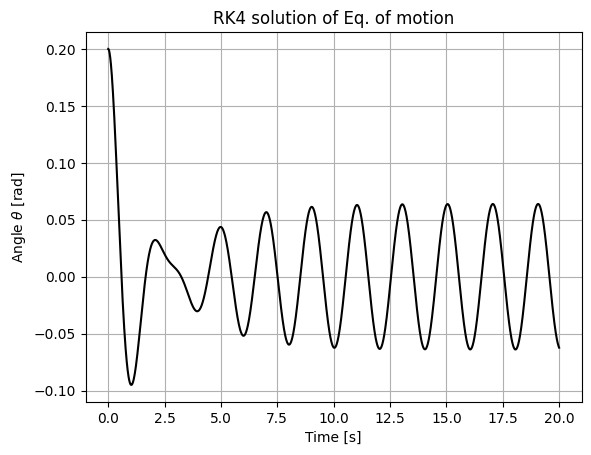

```python
def dF(u, t):
    """
    u : (omega, theta)
    t : float, t[i]
    """
    d_omega = drivkraft * np.sin(omega_D * t) - g / l * u[1] - q * u[0]
    return np.asarray((d_omega, u[0]))

u = solve(dF, step_RK4, t, u0=(omega_0, theta_0))
theta = u[:,1]

plt.plot(t, theta, c='k')
plt.title('RK4 solution of Eq. of motion')
plt.xlabel('Time [s]')
plt.ylabel(r'Angle $\theta$ [rad]')
plt.grid()
plt.show()
```

## Task 2

### Euler-Cromer implementation test

Here, we simply check that the solution calculated with the Euler-Cromer method results in a similar answer to Runge-Kutta 4. 1 decimal place is chosen.

```python
np.testing.assert_array_almost_equal(
    solve(dF, step_RK4, t, u0),
    solve(dF, step_EulerCromer, t, u0),
    decimal=1
)
```

### Convergence test implementation

Checks for convergence by calculating the energy at $t=t_0$ and $t=t_{\text{end}}$. The driving force and dampening needs to be set to zero in order to have energy conservation.

```python
N_dt = 100  # [--] Number of different time steps to estimate

dt_arr = np.linspace(0.001, .1, N_dt)
rk_error = np.zeros_like(dt_arr)
ec_error = np.zeros_like(dt_arr)

drivkraft = 0.
q = 0.

def error(u, u0, m=1., l=1.):
    e0 = (1/2) * m * l ** 2 * u0[0] ** 2 + (1/2) * m * 9.81 * l * u0[1] ** 2
    e1 = (1/2) * m * l ** 2 * u[0] ** 2 + (1/2) * m * 9.81 * l * u[1] ** 2
    return abs(e1 - e0)

for i, dt in enumerate(dt_arr):
    t = np.linspace(0, t_max, int(t_max//dt))

    rk_error[i] = error(
        solve(dF, step_RK4, t, u0)[-1], u0,
    )
    ec_error[i] = error(
        solve(dF, step_EulerCromer, t, u0)[-1], u0,
    )
```

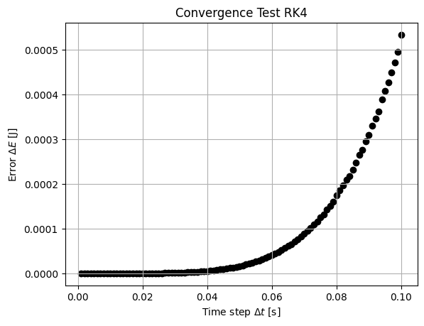

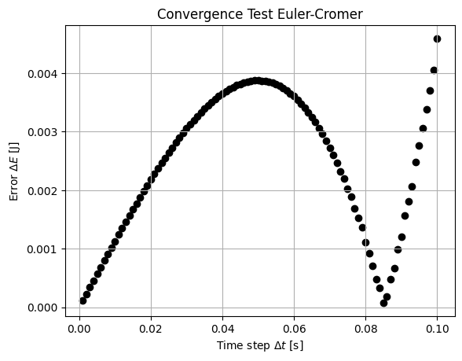

```python
plt.scatter(dt_arr, rk_error, c='k')
plt.title('Convergence Test RK4')
plt.ylabel(r'Error $\Delta E$ [J]')
plt.xlabel(r'Time step $\Delta t$ [s]')
plt.grid()
plt.show()

plt.scatter(dt_arr, ec_error, c='k')
plt.title('Convergence Test Euler-Cromer')
plt.ylabel(r'Error $\Delta E$ [J]')
plt.xlabel(r'Time step $\Delta t$ [s]')
plt.grid()
plt.show()
```

#### Runge-Kutta 4

We see an exponential growth in error with a linear increase in time step duration. As 0.01 < 0.02 which is an approximate upper limit for negligable error, the previous chosen time step is sufficient.

#### Euler-Cromer

Idk something is wrong

## Task 3

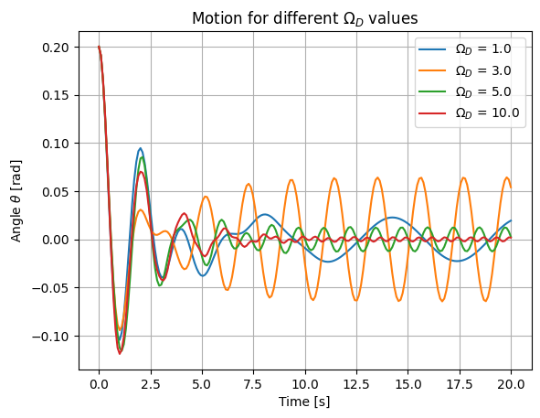

```python
q = 1.0          # [1/s]
drivkraft = 0.2  # [N] F_D / (m l)
omega_D_arr = (1, 3, 5, 10)

for omega_D in omega_D_arr:
    plt.plot(
        t, solve(dF, step_RK4, t, u0)[:,1],
        label=r'$\Omega_D$ = ' + f'{omega_D:.1f}'
    )

plt.title(r'Motion for different $\Omega_D$ values')
plt.xlabel('Time [s]')
plt.ylabel(r'Angle $\theta$ [rad]')
plt.legend()
plt.grid()
plt.show()
```

We observe that when $\Omega_D \approx 3.13\dots = \sqrt{g/l}$ the higher the amplitude gets. If $\Omega_D$ is above or below the systems resonant frequency, the amplitude will decrease. This is because if the driving frequency maches up with the systems normal modes, the forces will "work with the motion", instead of against, yielding the largest possible amplitude.

### Task 4

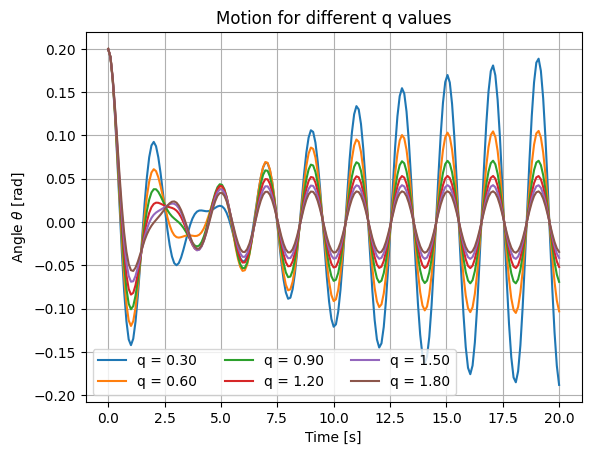

```python
omega_D = 3.13   # [1/s]
q_arr = np.arange(0.30, 2, 0.3)

for q in q_arr:
    plt.plot(
        t, solve(dF, step_RK4, t, u0)[:,1],
        label=f'q = {q:.2f}'
    )

plt.title(r'Motion for different q values')
plt.xlabel('Time [s]')
plt.ylabel(r'Angle $\theta$ [rad]')
plt.legend(loc='lower left',ncol=3)
plt.grid()
plt.show()
```

From the graph we observe that a lower friction parameter yields a generally higher amplitude. The systems resonant frequency stays the same.

### Task 5

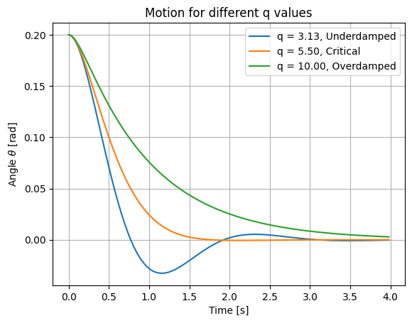

```python
drivkraft = 0.
t = np.arange(0, 4, 0.02)

for q, state in zip((3.13, 5.5, 10), ('Underdamped', 'Critical', 'Overdamped')):
    plt.plot(
        t, solve(dF, step_RK4, t, u0)[:,1],
        label=f'q = {q:.2f}, {state}'
    )

plt.title(r'Motion for different q values')
plt.xlabel('Time [s]')
plt.ylabel(r'Angle $\theta$ [rad]')
plt.legend(loc='upper right',ncol=1)
plt.grid()
plt.show()
```